# archeospec

Thu Jul 26 12:46:03 2018

## Dataset

This report includes the signatures for 30 files. A completed listing can be found at the end of the document.

### Parameters

The following parameters have been used:

- Unmixing Technique: VCA algorithm with 5 endmembers
- Clustering Technique: Kmeans algorithm with k=5
- No wavelength ranges have been cleaned at the beggining of the signature
- No wavelength ranges have been cleaned at the end of the signature
- No smoothing has been performed

## Visualization

The following figure shows the representation of every signature in the dataset. Colors are assigned at random.

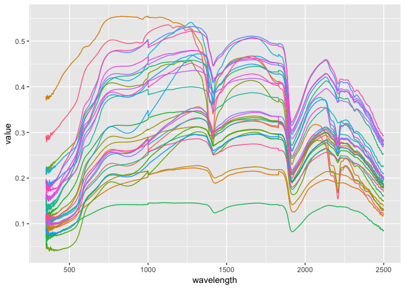

## Intracorrelation

The following figure measures the intracorrelation for each pair of wavelengths.

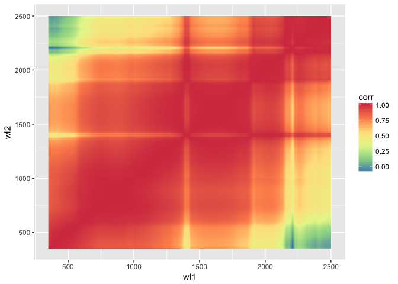

## Unmixing (VCA)

The following table and figure show the 5 endmembers selected by the VCA algorithm.

| endmember | file |
| --- | --- |
| end1 | signature0003.asd |
| end2 | signature0008.asd |
| end3 | signature0011.asd |
| end4 | signature0012.asd |
| end5 | signature0029.asd |

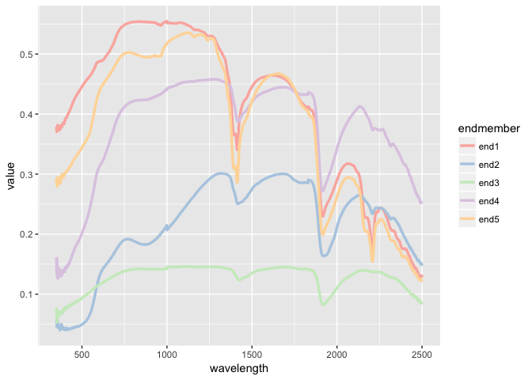

## Clustering (kmeans)

The following figure shows the error of the kmeans algorithm for incresing values of k, measured as the distance within clusters. The red dot represent the selected k value. The next figure shows the graphical representation of the dataset classified by the corresponding cluster assigned by kmeans.

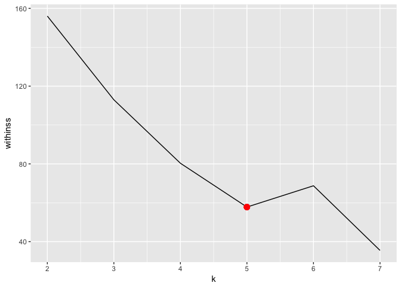

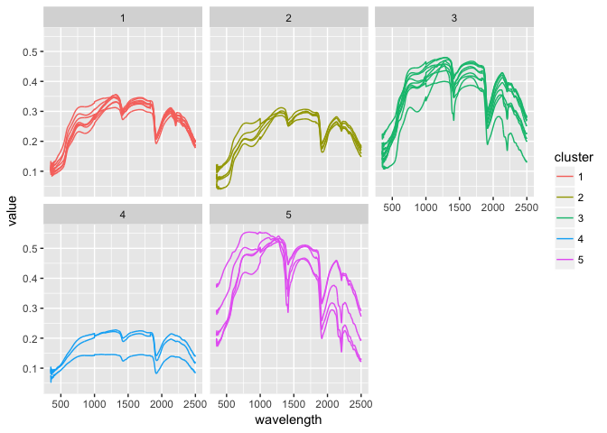

### Mutual Information

The following figure shows the mutual information for each wavelength and the assigned cluster as the averaged value for all the samples in the dataset.

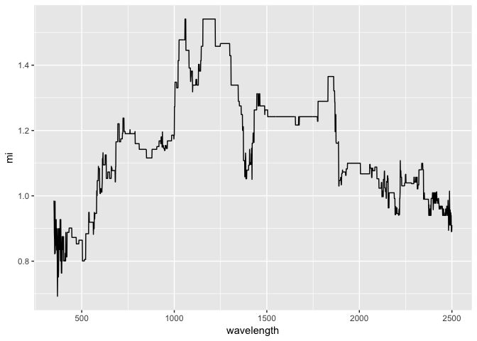

### Endmember classification

The next figure shows the correspondence between endmembers and clusters, note that kmeans can assign more than one ensemble to the same cluster, leaving some clusters unrepresented.

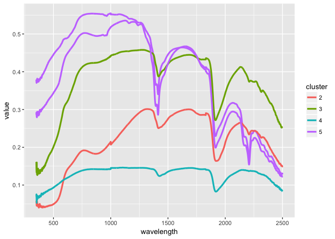

## Endmember weights by cluster

The next two figures show the average mixture for each cluster among all endmembers. In the barplot Each column represents a single cluster and averages the weights of the contained signatures. The different colored segments of the bar represent the weight proportion for each endmember. The boxplot is analogous, with each box representing the distribution of weight for a particular endmember, separated in an individual plot for each cluster.

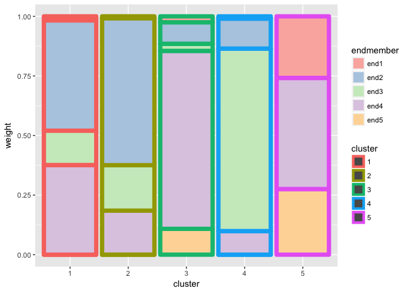

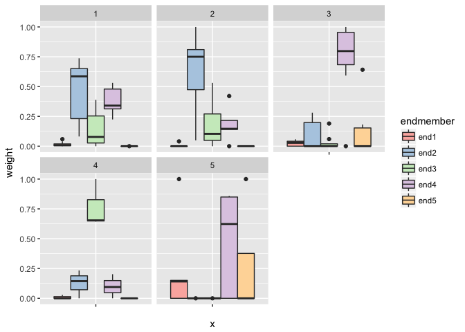

## Residual values

The following table and figure show the distribution of the residual component from the the unmixing process. The distribution includes all endmembers and signatures in the dataset.

| Min. | 1st Qu. | Median | Mean | 3rd Qu. | Max. |
| --- | --- | --- | --- | --- | --- |
| 0 | 6.973429 | 13.71946 | 23.92003 | 23.84471 | 103.0857 |

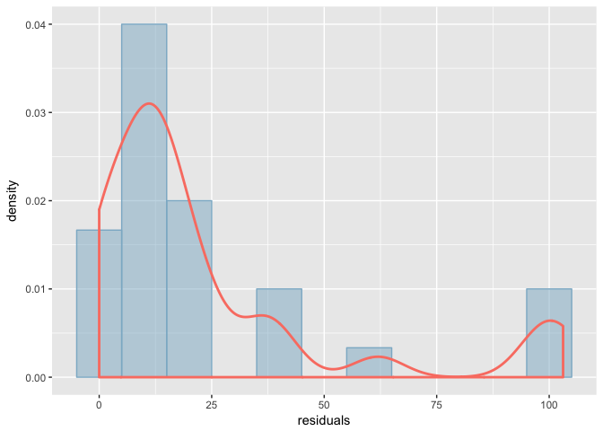

## Summary table

| file | end1 | end2 | end3 | end4 | end5 | residual |
| --- | --- | --- | --- | --- | --- | --- |
| signature0000.asd | 0.0114823 | 0.7368873 | 0.0274285 | 0.2242018 | 0.0000000 | 15.956950 |
| signature0001.asd | 0.0414054 | 0.6331557 | 0.0464189 | 0.2790201 | 0.0000000 | 13.080670 |
| signature0002.asd | 0.0285372 | 0.2332579 | 0.6432487 | 0.0949562 | 0.0000000 | 8.531558 |
| signature0003.asd | 1.0000000 | 0.0000000 | 0.0000000 | 0.0000000 | 0.0000000 | 0.000000 |
| signature0004.asd | 0.0000000 | 0.1439404 | 0.6538356 | 0.2022239 | 0.0000000 | 10.362773 |
| signature0005.asd | 0.0000000 | 0.1391133 | 0.3882184 | 0.4726683 | 0.0000000 | 6.454053 |
| signature0006.asd | 0.0118917 | 0.2620033 | 0.2283307 | 0.4977743 | 0.0000000 | 11.179555 |
| signature0007.asd | 0.0579847 | 0.2810929 | 0.0197757 | 0.0000000 | 0.6411468 | 5.528295 |
| signature0008.asd | 0.0000000 | 1.0000000 | 0.0000000 | 0.0000000 | 0.0000000 | 0.000000 |
| signature0009.asd | 0.0000000 | 0.8100577 | 0.0485625 | 0.1413798 | 0.0000000 | 14.224279 |
| signature0010.asd | 0.0589223 | 0.0813605 | 0.3288604 | 0.5308568 | 0.0000000 | 5.262400 |
| signature0011.asd | 0.0000000 | 0.0000000 | 1.0000000 | 0.0000000 | 0.0000000 | 0.000000 |
| signature0012.asd | 0.0000000 | 0.0000000 | 0.0000000 | 1.0000000 | 0.0000000 | 0.000000 |
| signature0013.asd | 0.0402067 | 0.4739234 | 0.2704024 | 0.2154675 | 0.0000000 | 13.214638 |
| signature0014.asd | 0.0414215 | 0.0000000 | 0.1898640 | 0.7687146 | 0.0000000 | 9.553423 |
| signature0015.asd | 0.0000000 | 0.5379121 | 0.1083741 | 0.3537138 | 0.0000000 | 23.940883 |
| signature0016.asd | 0.0000000 | 0.0000000 | 0.0000000 | 0.6232451 | 0.3767549 | 61.972060 |
| signature0017.asd | 0.0000000 | 0.2025992 | 0.0000000 | 0.7974008 | 0.0000000 | 97.366481 |
| signature0018.asd | 0.0332148 | 0.1303983 | 0.0000000 | 0.6834973 | 0.1528896 | 35.336380 |
| signature0019.asd | 0.0000000 | 0.7499646 | 0.1036880 | 0.1463473 | 0.0000000 | 23.556173 |
| signature0020.asd | 0.1505177 | 0.0000000 | 0.0000000 | 0.8494823 | 0.0000000 | 100.316748 |
| signature0021.asd | 0.0058344 | 0.6672872 | 0.0000000 | 0.3268785 | 0.0000000 | 15.155880 |
| signature0022.asd | 0.0166067 | 0.0000000 | 0.0000000 | 0.9833933 | 0.0000000 | 37.110530 |
| signature0023.asd | 0.0000000 | 0.0000000 | 0.0595197 | 0.9404803 | 0.0000000 | 22.002954 |
| signature0024.asd | 0.0061495 | 0.6451792 | 0.0245259 | 0.3241454 | 0.0000000 | 14.868551 |
| signature0025.asd | 0.0456410 | 0.0000000 | 0.0000000 | 0.9543590 | 0.0000000 | 40.123986 |
| signature0026.asd | 0.0283015 | 0.1980235 | 0.0000000 | 0.5921959 | 0.1814791 | 18.450872 |
| signature0027.asd | 0.1411209 | 0.0000000 | 0.0000000 | 0.8588791 | 0.0000000 | 103.085697 |
| signature0028.asd | 0.0000000 | 0.0485195 | 0.5307606 | 0.4207199 | 0.0000000 | 10.964994 |
| signature0029.asd | 0.0000000 | 0.0000000 | 0.0000000 | 0.0000000 | 1.0000000 | 0.000000 |

## About archeospec

This report has been generated automatically using the archeospec package version 1.0.1.